# PCA analysis of Gat201 RNA-seq dataset

Liz Hughes and Edward Wallace

2021-12-16

# Summary

This document is a big-picture analysis of trends in the Gat201 RNA-seq dataset.

The first goal is a principal component analysis (PCA) to show the main axes of variation in the data.

This outputs a PCA plot and supplementary plot:

- results/PC12_plot_GAT201RNAseq.svg (Figure 3B of manuscript)
- results/PCmultipanel_plot_GAT201RNAseq.png (Figure S6)

# Load packages used for analysis

# Load count data and remove unwanted parts of column names

```r
# note: we should insist that counts are loaded as integers
# and check the other data types
counts <-
  here::here("quantseqfwd_EH_050221", "counts.txt") %>%
  readr::read_tsv(comment = "#") %>%
  dplyr::rename_with(str_remove_all, pattern = "_S[0-9]+_R1_001_aln.bam")
```

# Load sample sheet and format for DESeq2’s requirements: readxl::read_excel

```r
samplesheet <-
    here::here("input_experiment", "Gat201_samplesheet.xlsx") %>%
    readxl::read_excel() %>%
    magrittr::set_rownames(.$SampleID) %>%
    dplyr::mutate(GAT201 =
                    forcats::fct_collapse(Strain,
                                          "WT" = c("a","A"),
                                          "del" = c("B","M")) %>%
                    forcats::fct_relevel("del")
                  )
```

# Select counts

```r
counts_all <-
      dplyr::select(counts, samplesheet$SampleID) %>%
      magrittr::set_rownames(counts$Geneid)
```

# Construct the data object from the matrix of counts and the samplesheet information table

```r
dds_all <- DESeqDataSetFromMatrix(countData = counts_all,
                                   colData = samplesheet,
                                   design = ~ Condition  + Time + GAT201)
```

# rlog transformation

```r
rld_all <- rlog(dds_all)
head(assay(rld_all))
```

```
##                    1         2        3         4       5b         6        7
## CNAG_00002  8.754840 10.343840 8.823345  8.443942 8.681945 10.416515 8.834259
## CNAG_00003  7.977184  6.966253 6.575968  6.887152 7.827133  6.883900 6.800443
## CNAG_00004  8.285381  8.243997 7.579837  7.130943 8.205970  8.194406 7.367782
## CNAG_00005  9.100014  8.939314 8.764728  8.386466 8.533863  8.850015 8.937491
## CNAG_00006 10.306203  9.565392 9.937058 10.177375 9.905369  9.548736 9.979532
## CNAG_00007  7.681137  9.211125 8.620862  8.458208 7.901747  9.113592 8.683574
##                    8         9        10        11        12       13        14
## CNAG_00002  8.394622 10.253651  8.776026  8.370362 10.458688 8.957433  8.420642
## CNAG_00003  6.782918  7.197444  6.747447  6.735191  7.068382 6.667859  6.486296
## CNAG_00004  7.413073  8.189683  7.824203  7.455033  8.276967 7.588608  7.398294
## CNAG_00005  8.313652  9.170730  9.053895  8.350017  9.063553 8.916345  8.423907
## CNAG_00006 10.198612  9.723669 10.016086 10.240084  9.621604 9.952586 10.271052
## CNAG_00007  8.340636  9.334206  8.671691  8.631586  9.423569 8.883706  8.589471
##                   15        16       17        18        19        20       21
## CNAG_00002  8.933495 10.450413 8.914310  8.477705  8.930142 10.499717 8.876647
## CNAG_00003  7.850142  7.012786 6.865562  6.881818  7.489894  7.060078 6.614772
## CNAG_00004  8.091698  8.169180 7.548043  7.233457  8.163397  8.170167 7.711114
## CNAG_00005  8.901122  8.868831 8.756146  8.180595  9.104493  8.987268 8.729237
## CNAG_00006 10.102668  9.542429 9.975105 10.016891 10.342790  9.614300 9.998832
## CNAG_00007  7.881267  9.259682 8.730824  8.372927  7.763678  9.253728 8.761705
##                   22        23       24        25        26        27        28
## CNAG_00002  8.582865 10.492107 8.796192  8.387656 10.570651  9.013045  8.407413
## CNAG_00003  6.706762  7.011772 6.923658  6.578410  7.061011  6.811347  6.500275
## CNAG_00004  7.321848  8.257257 7.631595  7.418984  8.228817  7.538623  7.275987
## CNAG_00005  8.180989  9.101546 8.964531  8.356604  9.084698  8.910422  8.164935
## CNAG_00006 10.157834  9.633529 9.977944 10.122618  9.566092 10.107835 10.187882
## CNAG_00007  8.328067  9.171016 8.815515  8.564518  9.278755  8.984203  8.568854
##                  29b        30       31        32        33        34        35
## CNAG_00002  9.334531 10.405446 8.626686  8.605483  9.356104 10.411449  8.954610
## CNAG_00003  7.859369  6.845315 6.541454  6.358068  7.855819  6.936405  6.843567
## CNAG_00004  7.988498  7.883949 7.476611  7.250637  7.966506  7.931587  7.493754
## CNAG_00005  8.769806  8.892066 8.908186  8.498512  8.932057  8.911164  9.113845
## CNAG_00006 10.195925  9.614672 9.940306 10.303354 10.189526  9.607375 10.027507
## CNAG_00007  7.664435  9.337668 8.657560  8.578542  7.708854  9.230003  8.719525
##                   36        37        38        39        40        41
## CNAG_00002  8.570956 10.385430  8.956103  8.455614 10.603292  8.860934
## CNAG_00003  6.250674  7.146386  7.109772  6.433794  7.064271  7.001137
## CNAG_00004  7.232440  8.035893  7.698301  7.371792  8.236442  7.542188
## CNAG_00005  8.766402  9.710160  9.359717  8.474088  9.331626  9.627885
```

[output cut: 8 more lines]

```
## CNAG_00007  8.759327  7.646055  9.178676  8.790714  8.546172  7.736238
##                   48       49        50        51        52        53        54
## CNAG_00002 10.296873 9.109590  8.817144 10.378544  8.780898  8.448410 10.534125
## CNAG_00003  6.468055 6.995892  6.456664  6.858985  6.875372  6.401096  6.942474
## CNAG_00004  8.164158 7.713008  7.253749  8.058885  7.444963  7.326496  8.374614
## CNAG_00005  8.994491 9.315845  8.613660  9.560160  9.615240  8.624831  9.684476
## CNAG_00006  9.769690 9.948950 10.248051  9.762597 10.179798 10.430520  9.848515
## CNAG_00007  9.441023 8.660745  8.682578  9.441656  8.867592  8.735428  9.420521
##                   55        56
## CNAG_00002  8.953196  8.732771
## CNAG_00003  6.777329  6.549142
## CNAG_00004  7.531828  7.331251
## CNAG_00005  9.540064  8.713476
## CNAG_00006 10.110537 10.439966
## CNAG_00007  8.897945  8.790893
```

## Calculate principal components of rlog

```r
## calculate the principal components sample-wise
pca_rlog <- prcomp(t(assay(rld_all)))

# combine pc projections to samples with sample sheet
pcdf_rlog <- bind_cols(
  as_tibble(colData(rld_all)) %>%
    mutate(GAT201_Cond = interaction(GAT201, Condition, sep = "_"),
           GAT201_Serum = forcats::fct_collapse(
             GAT201_Cond,
             "del_none"   = c("del_R", "del_Y"),
             "WT_none"   = c("WT_R", "WT_Y"),
             "del_Serum" = "del_RS",
             "WT_Serum"  = "WT_RS"
           ),
    ),
  as_tibble(pca_rlog$x)
)

propvar_rlog_df <- tibble(
  PC = seq.int(1L, ncol(pca_rlog$x) ),
  prop_var = pca_rlog$sdev^2/sum(pca_rlog$sdev^2)
)
```

# Plot PCA percentage variance explained to find how many PCs to pay attention to.

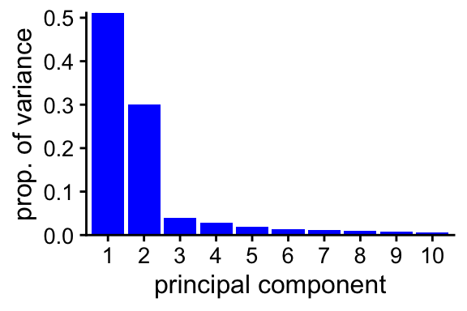

```r
plot_percentvar_rlog <-
  ggplot(data = propvar_rlog_df,
         aes(x = PC, y = prop_var)) +
  geom_col(fill = "blue") +
  scale_x_continuous("principal component",
                     limits = c(0.4,10.6),
                     # hack xlim to include the bars and a little space.
                     breaks = 1L:10L,
                     expand = c(0,0)) +
  scale_y_continuous("prop. of variance", expand = c(0,0)) +
  theme(panel.grid.major = element_blank())

plot_percentvar_rlog
```

# Plot PC1 vs PC2 with default values

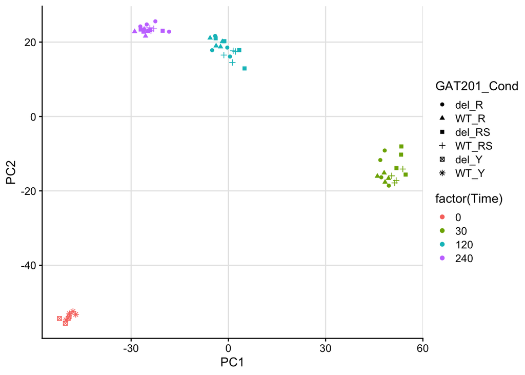

```r
ggplot(data = pcdf_rlog,
       aes(colour = factor(Time),
           shape = GAT201_Cond)
       ) +
  geom_point(aes(x = PC1, y = PC2))
```

# Plot PC1 vs PC2 prioritising Time and GAT201_serum

This is figure 3B of manuscript

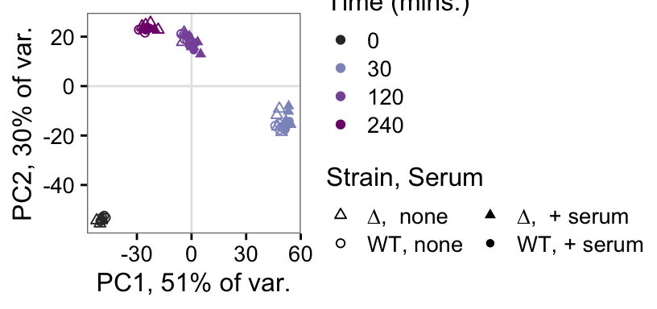

```r
plot_PCA_Time_GC <- function(xpc = "PC1", ypc = "PC2",
                             data = pcdf_rlog) {
  # Plots PCA with default settings to highlight:
  #  Time as colour
  #  GAT201_Serum as shape, i.e. interaction of GAT201 and serum
  #    (treating R and Y both as "no serum")
  #
  # Default data input is pcdf_rlog, but it should work with others
  # as long as they have Time and GAT201_Serum as variables.

  ggplot(data = data,
         aes(colour = factor(Time),
             shape = GAT201_Serum)
  ) +
    geom_vline(xintercept = 0, colour = "grey90", size = 0.5) +
    geom_hline(yintercept = 0, colour = "grey90", size = 0.5) +
    geom_point(aes_string(x = xpc, y = ypc)) +
    scale_shape_manual("Strain, Serum",
                       guide = guide_legend(ncol= 2),
                       values = c("del_none"   = 2,
                                  "WT_none"   = 1,
                                  "del_Serum" = 17,
                                  "WT_Serum"  = 16),
                       labels = c("del_none"   = "∆,  none",
                                  "WT_none"   = "WT, none",
                                  "del_Serum" = "∆,  + serum",
                                  "WT_Serum"  = "WT, + serum")
    ) +
    scale_colour_manual("Time (mins.)",
                        values = c("0" = "grey20",
                                   "30" = "#8c96c6",
                                   "120" = "#8856a7",
                                   "240" = "#810f7c")) +
    theme(axis.line = element_blank(),
          panel.grid.major = element_blank(),
          panel.border = element_rect(colour= "grey50", size = 0.5))

}

plot_PC12_fancy <-
  plot_PCA_Time_GC("PC1", "PC2")  +
  labs(x = paste0("PC1, ",
                  round(propvar_rlog_df$prop_var[1] * 100),
                  "% of var."),
       y  = paste0("PC2, ",
                   round(propvar_rlog_df$prop_var[2] * 100),
                   "% of var."))

plot_PC12_fancy
```

This plot shows that PC1 and PC2 are almost completely reporting on Time. Because PC1/2 collectively explain 80% of the variance, that establishes that Time is the biggest driver of variability.

```r
ggsave(here::here("results", "PC12_plot_GAT201RNAseq.svg"),
       plot_PC12_fancy, height = 2, width = 4.25)
```

## Make aligned plot of first 4 PCs

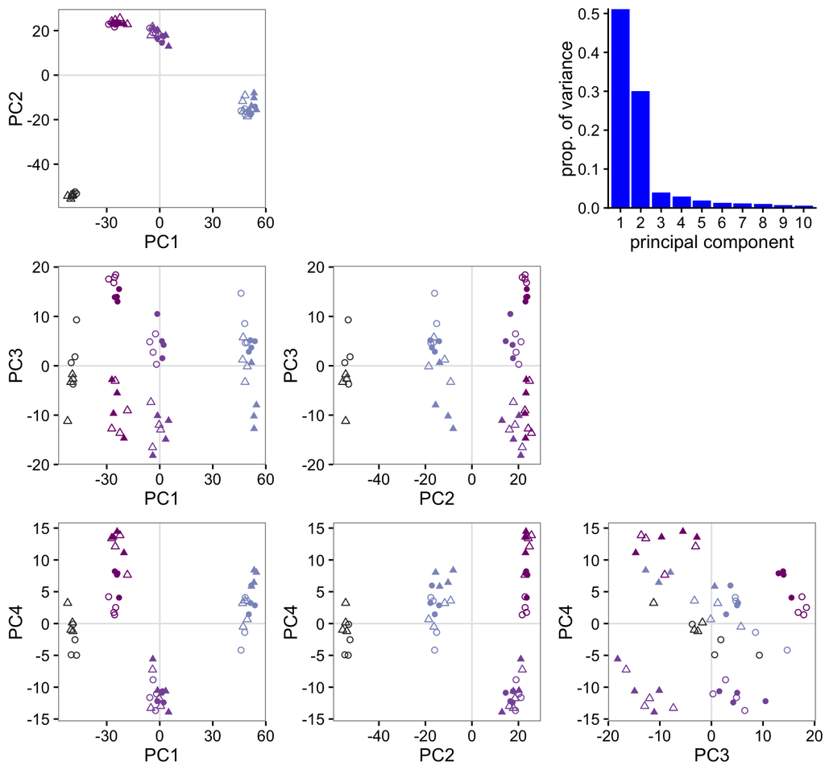

```r
# Create plot panels but without legends
PC1vs2 <- plot_PCA_Time_GC("PC1", "PC2") + theme(legend.position = "none")
PC1vs3 <- plot_PCA_Time_GC("PC1", "PC3") + theme(legend.position = "none")
PC1vs4 <- plot_PCA_Time_GC("PC1", "PC4") + theme(legend.position = "none")
PC2vs3 <- plot_PCA_Time_GC("PC2", "PC3") + theme(legend.position = "none")
PC2vs4 <- plot_PCA_Time_GC("PC2", "PC4") + theme(legend.position = "none")
PC3vs4 <- plot_PCA_Time_GC("PC3", "PC4") + theme(legend.position = "none")

# get the legend
PC_legend_Time_GC <- get_legend(
  plot_PCA_Time_GC() +
    theme(legend.position = c(0.05, 0.6),
      legend.box.margin = margin(4, 5, 4, 4),
          legend.box.background = element_rect(colour= "grey50", size = 0.25))
  )

# plot those aligned in a grid

plot_grid(PC1vs2, PC_legend_Time_GC,plot_percentvar_rlog,
          PC1vs3, PC2vs3, NULL,
          PC1vs4, PC2vs4, PC3vs4,
          ncol = 3,
          align = "hv")
```

```r
ggsave(here::here("results", "PCmultipanel_plot_GAT201RNAseq.png"),
       height = 7, width = 7.5)
```

This plot shows that PC3 reports on Gat201 status, vs WT.

It is unclear what PC4 means.

## PC5 somewhat reports on serum at the later time points

Clearest report in PC2 vs PC5, because PC2 lays out the times in the expected order.

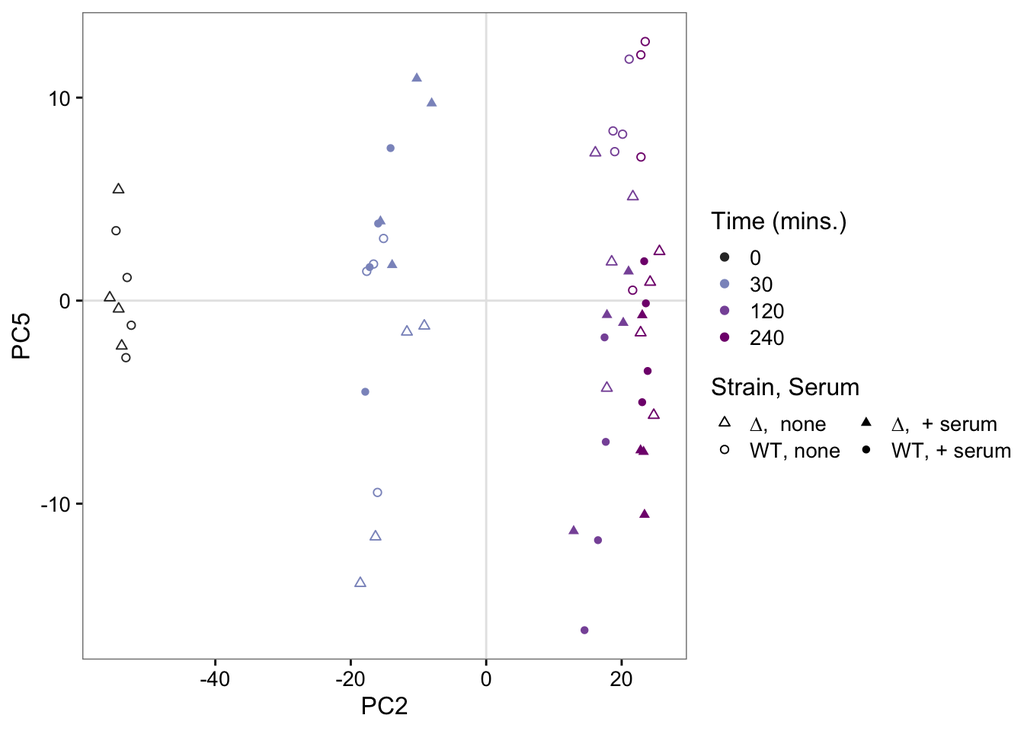

```r
plot_PCA_Time_GC("PC2", "PC5")
```